# 팀프로젝트 제안서

Team 3

2024-05-02

수업 시간에 편성된 팀별로 프로젝트에 대한 회의를 통하여 프로젝트 제안서 (기획서)를 제출합니다.

제출 형식과 필수 포함 내용은 하기와 같습니다.

- 제출 형식: R Markdown
- 필수 포함 내용:
- 프로젝트에 활용하고자 하는 데이터 설명 및 간략한 원본 데이터 요약 결과 (데이터 전처리 불필요)
- 데이터 분석 목적 (가안으로 작성하며, 향후 변경 가능)
- 데이터 분석 절차 (가안으로 작성하며, 향후 변경 가능)
- 도출 예정 결과물 (가안으로 작성하며, 향후 변경 가능)
- 팀별 역할 구성 (인원 별 담당 역할과 비중 (합계 100% 기준으로 분담))

팀별로 1건의 제안서를 제출하는 관계로, 본 과제의 평가는 팀별로 이루어질 예정인 점 참고 부탁드립니다.

감사합니다.

### 프로젝트에 활용하고자 하는 데이터 설명 및 간략한 원본 데이터 요약 결과

data from kaggle: https://www.kaggle.com/datasets/shivamb/machine-predictive-maintenance-classification

### Machine Predictive Maintenance Classification

```r
#데이터 불러오기
dat <- read.csv('predictive_maintenance.csv')
head(dat)
```

```
##   UDI Product.ID Type Air.temperature..K. Process.temperature..K.
## 1   1     M14860    M               298.1                   308.6
## 2   2     L47181    L               298.2                   308.7
## 3   3     L47182    L               298.1                   308.5
## 4   4     L47183    L               298.2                   308.6
## 5   5     L47184    L               298.2                   308.7
## 6   6     M14865    M               298.1                   308.6
##   Rotational.speed..rpm. Torque..Nm. Tool.wear..min. Target Failure.Type
## 1                   1551        42.8               0      0   No Failure
## 2                   1408        46.3               3      0   No Failure
## 3                   1498        49.4               5      0   No Failure
## 4                   1433        39.5               7      0   No Failure
## 5                   1408        40.0               9      0   No Failure
## 6                   1425        41.9              11      0   No Failure
```

```r
summary(dat)
```

```
##       UDI         Product.ID            Type           Air.temperature..K.
##  Min.   :    1   Length:10000       Length:10000       Min.   :295.3
##  1st Qu.: 2501   Class :character   Class :character   1st Qu.:298.3
##  Median : 5000   Mode  :character   Mode  :character   Median :300.1
##  Mean   : 5000                                         Mean   :300.0
##  3rd Qu.: 7500                                         3rd Qu.:301.5
##  Max.   :10000                                         Max.   :304.5
##  Process.temperature..K. Rotational.speed..rpm.  Torque..Nm.    Tool.wear..min.
##  Min.   :305.7           Min.   :1168           Min.   : 3.80   Min.   :  0
##  1st Qu.:308.8           1st Qu.:1423           1st Qu.:33.20   1st Qu.: 53
##  Median :310.1           Median :1503           Median :40.10   Median :108
##  Mean   :310.0           Mean   :1539           Mean   :39.99   Mean   :108
##  3rd Qu.:311.1           3rd Qu.:1612           3rd Qu.:46.80   3rd Qu.:162
##  Max.   :313.8           Max.   :2886           Max.   :76.60   Max.   :253
##      Target       Failure.Type
##  Min.   :0.0000   Length:10000
##  1st Qu.:0.0000   Class :character
##  Median :0.0000   Mode  :character
##  Mean   :0.0339
##  3rd Qu.:0.0000
##  Max.   :1.0000
```

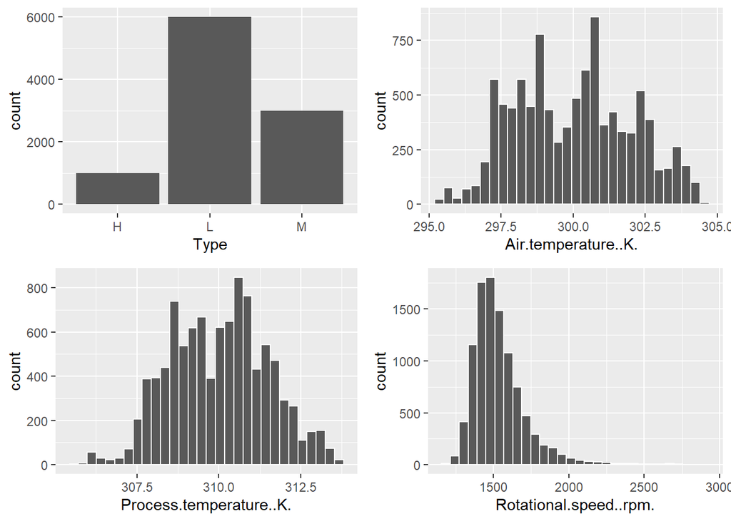

```r
# UDI, Product.ID 제외하고 시각화
#install.packages("gridExtra")

library(ggplot2)
library(gridExtra)

dat <- dat[,3:10]
dat$Target <- as.character(dat$Target)

visualize <- function(x){
  if (is.character(x)){
    ggplot() + geom_bar(aes(x))
  } else {
    ggplot() + geom_histogram(aes(x), color="white")
  }
}

g1 <- visualize(dat[,1]) + xlab(colnames(dat)[1])
g2 <- visualize(dat[,2]) + xlab(colnames(dat)[2])
g3 <- visualize(dat[,3]) + xlab(colnames(dat)[3])
g4 <- visualize(dat[,4]) + xlab(colnames(dat)[4])

g5 <- visualize(dat[,5]) + xlab(colnames(dat)[5])
g6 <- visualize(dat[,6]) + xlab(colnames(dat)[6])
g7 <- visualize(dat[,7]) + xlab(colnames(dat)[7])
g8 <- visualize(dat[,8]) + xlab(colnames(dat)[8]) + theme(axis.text.x = element_text(angle = 90, hjust = 1, vjust = 0.5 ))



grid.arrange(g1, g2, g3, g4, ncol=2)
```

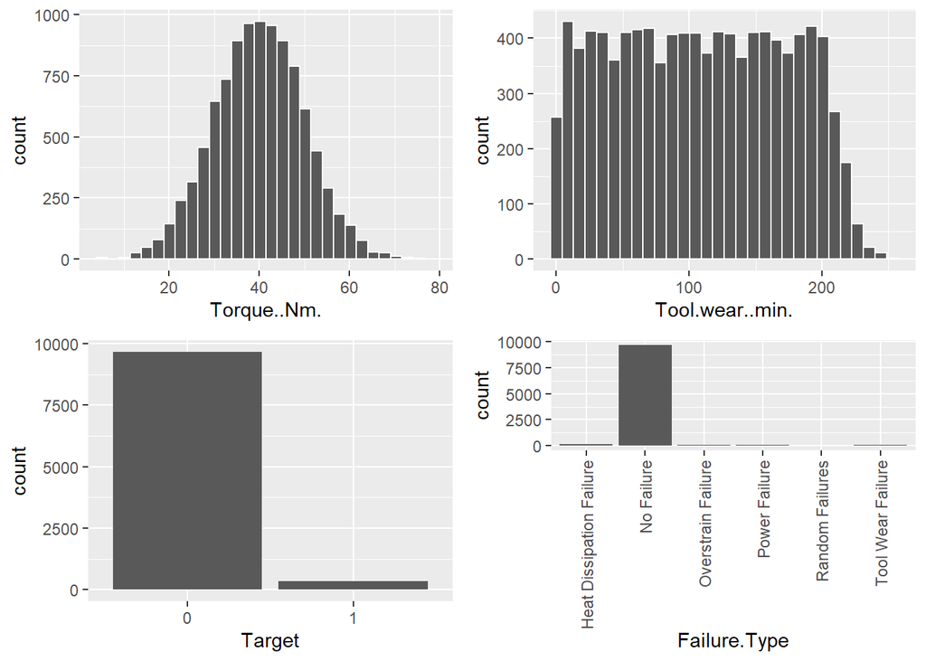

```r
grid.arrange(g5, g6, g7, g8, ncol=2)
```

### 데이터 분석 목적 (가안으로 작성하며, 향후 변경 가능)

1. 공작 기계(milling machine) 고장이 발생하거나 발생 시점을 예측하는 모델 생성을 목적으로 한다.
2. 고장유형 별 원인을 확인 및 분석하고자 한다.
3. 과거 데이터를 분석하고 패턴과 지표를 식별함으로써 조기 경고나 경고를 제공하여 사전 예방적 유지 보수를 가능하게 하고 다운타임을 최소화시키는 것을 목적으로 한다.

### 데이터 분석 절차 (가안으로 작성하며, 향후 변경 가능)

1. 데이터 전처리 및 시각화 데이터 내의 이상치 및 누락치를 확인하여 제거, 데이터 columnn명의 ’.’을 제거하고 이후에 모델 개발에 필요한 신규피쳐가 있다면 생성 시각화를 통하여 분포를 확인하고 데이터분석에 활용
2. 데이터 간의 상관관계 분석 데이터의 변수들간의 상관관계를 분석하고 다중공선성을 고려한 변수 추출
3. 고장 예측 모델 개발 전처리된 데이터를 사용하여 머신러닝을 통해 예측모델을 학습 및 개선
4. 고장 예측 모델 평가 및 검증 회귀분석, svm 등 다양한 모델을 비교하여 모델 정확성을 평가하고 가장 성능이 좋은 모델을 선정

### 팀별 역할 구성 (인원 별 담당 역할과 비중 (합계 100% 기준으로 분담))

이승환: 데이터 전처리 및 시각화, 회귀분석, 발표자료제작(20%) 나재영: 상관관계 분석, 고장예측모델 (20%) 강상빈: 회귀분석, 제안서 작성(20%) 조준형: 고장예측모델, 고장 별 원인 탐색(20%) 안하윤: 고장예측모델, 발표 (20%)